# Numpy

NumPy’s main object is the homogeneous multidimensional array. It is a table of elements (usually numbers), all of the same type, indexed by a tuple of positive integers.

## • Example of array creation:

```python
import numpy as np
arr = np.array( [[ 1, 2, 3],
                [ 4, 2, 5]] )
print(arr)
```

```
[[1 2 3]
 [4 2 5]]
```

```python
#creating arrays
np.zeros(10, dtype='int')
```

```
array([0, 0, 0, 0, 0, 0, 0, 0, 0, 0])
```

```python
#creating a 3 row x 5 column matrix
np.ones((3,5), dtype=float)
```

```
array([[1., 1., 1., 1., 1.],
       [1., 1., 1., 1., 1.],
       [1., 1., 1., 1., 1.]])
```

```python
#creating a matrix with a predefined value
np.full((3,5),1.23)
```

```
array([[1.23, 1.23, 1.23, 1.23, 1.23],
       [1.23, 1.23, 1.23, 1.23, 1.23],
       [1.23, 1.23, 1.23, 1.23, 1.23]])
```

```python
#create an array with a set sequence
np.arange(0, 20, 2)
```

```
array([ 0,  2,  4,  6,  8, 10, 12, 14, 16, 18])
```

```python
#create an array of even space between the given range of values
np.linspace(0, 1, 5)
```

```
array([0.  , 0.25, 0.5 , 0.75, 1.  ])
```

```python
#create a 3x3 array with mean 0 and standard deviation 1 in a given dimension
np.random.normal(0, 1, (3,3))
```

```
array([[-1.2808322 , -0.64696912, -0.28088191],
       [-1.30026909,  0.64832559, -1.13104444],
       [ 1.5971886 ,  1.1003282 ,  0.04518811]])
```

## Array Slicing

**Syntax:** a[start:stop:step]

```python
x = np.arange(10)
x
```

```
array([0, 1, 2, 3, 4, 5, 6, 7, 8, 9])
```

```python
#from start to 4th position
x[:5]
```

```
array([0, 1, 2, 3, 4])
```

```python
#from 4th to 6th position
x[4:7]
```

```
array([4, 5, 6])
```

```python
#return elements at even place
x[ : : 2]
```

```
array([0, 2, 4, 6, 8])
```

## List Comprehension

```python
L = list(range(10))
[str(c) for c in L]
```

```
['0', '1', '2', '3', '4', '5', '6', '7', '8', '9']
```

## Shape Manipulation

**Syntax:** numpy.reshape(a, newshape)

```python
x = np.array([[2,3,4], [5,6,7]])
np.reshape(x, (3, 2))
```

```
array([[2, 3],
       [4, 5],
       [6, 7]])
```

## Reading Files in numPy

**Syntax:** numpy.load()

# Pandas

## Creating DataFrame:

1. Creating Pandas DataFrame from lists of lists.

```python
import pandas as pd
# initialize list of lists
data = [['tom', 10], ['nick', 15], ['juli', 14]]
# Create the pandas DataFrame
df = pd.DataFrame(data, columns = ['Name', 'Age'])
df
```

|  | Name | Age |
| --- | --- | --- |
| 0 | tom | 10 |
| 1 | nick | 15 |
| 2 | juli | 14 |

1. Creating DataFrame from dict of narray/lists.

```python
import pandas as pd
# intialise data of lists.
data = {'Name':['Tom', 'nick', 'krish', 'jack'], 'Age':[20, 21, 19, 18]}
# Create DataFrame
df = pd.DataFrame(data)
df
```

|  | Name | Age |
| --- | --- | --- |
| 0 | Tom | 20 |
| 1 | nick | 21 |
| 2 | krish | 19 |
| 3 | jack | 18 |

1. Creates a indexes DataFrame using arrays.

```python
import pandas as pd
# initialise data of lists.
data = {'Name':['Tom', 'Jack', 'nick', 'juli'], 'marks':[99, 98, 95, 90]}
# Creates pandas DataFrame.
df = pd.DataFrame(data, index =['rank1', 'rank2', 'rank3', 'rank4'])
df
```

|  | Name | marks |
| --- | --- | --- |
| rank1 | Tom | 99 |
| rank2 | Jack | 98 |
| rank3 | nick | 95 |
| rank4 | juli | 90 |

## Reading Files in pandas

data = pd.read_csv("filename.csv")

```python
import pandas as pd
```

```python
from google.colab import drive
drive.mount('/content/drive')
```

[output not shown]

```python
data = pd.read_csv('/content/drive/My Drive/Colab Notebooks/student_scores.csv')
data.head()
```

|  | X | Y |
| --- | --- | --- |
| 0 | 2.5 | 21 |
| 1 | 5.1 | 47 |
| 2 | 3.2 | 27 |
| 3 | 8.5 | 75 |
| 4 | 3.5 | 30 |

## String Slice manipulation

**Syntax:** str.slice(start, stop, step)

## Export to CSV File:

df.to_csv(r'Path where you want to store the exported CSV file\FileName.csv')

# Matplotlib

## Installing Matplotlib

python -m pip install -U matplotlib

## Import Matplotlib

import matplotlib.pyplot as plt

```python
import matplotlib.pyplot as plt
```

## Simple line chart

In Matplotlib we can create a line chart by calling the plot method. We can also plot multiple columns in one graph, by looping through the columns we want and plotting each column on the same axis.

[figure not shown]

## Histogram

In Matplotlib we can create a Histogram using the hist method. If we pass it categorical data like the points column from the wine-review dataset it will automatically calculate how often each class occurs.

[figure not shown]

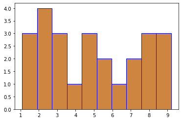

```python
plt.hist(data['X'],facecolor='peru',edgecolor="blue")
plt.show()
```

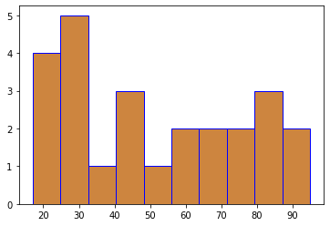

```python
plt.hist(data['Y'],facecolor='peru',edgecolor="blue")
plt.show()
```

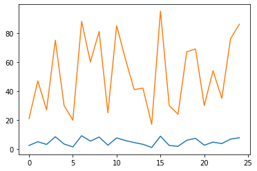

```python
plt.plot(data)
```